# Analysis World Happiness Report in 2019 with Regression Model

Gasha Sarwono

2-May-2021

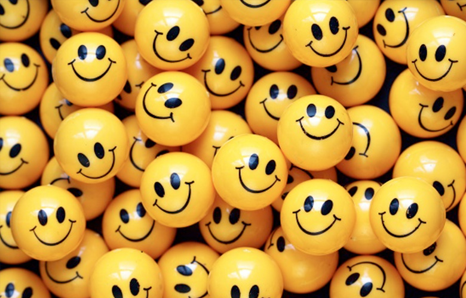

### Background

#### The Data is a survey about happiness which contains aspects of happiness

#### My Purpose using this data is to predict the important factors that influence of happiness

#### Data Description:

##### Score: Score of happiness

##### GDP.per.capita: Effect Gross Domestic Product per capita

##### Social.support: Effect Social Support

##### Healthy.life.expectancy: Effect Health Life Expectancy

##### Freedom.to.make.life.choices: Effect Freedom Life Choices

##### Generosity: Effect to help each other

##### Perceptions.of.corruption: Effect incident corruption

#### The data I get from Kaggle with this following link:

#### https://www.kaggle.com/unsdsn/world-happiness

### Set Up

**Activated library**

```r
library(GGally) #check correlation
library(dplyr) #piping daya
library(rsample) #sampling data
library(tidyverse) #wrangling data
library(lmtest) #check assumption
library(car) #check vif
library(MLmetrics) #calculate error
```

**Import Data**

Import data csv

```r
rawdata <- read.csv("2019.csv", sep=",")
rawdata
```

| Overall.rank | Country.or.region | Score | GDP.per.capita | Social.support | Healthy.life.expectancy | Freedom.to.make.life.choices | Generosity | Perceptions.of.corruption |
| --- | --- | --- | --- | --- | --- | --- | --- | --- |
| 1 | Finland | 7.769 | 1.340 | 1.587 | 0.986 | 0.596 | 0.153 | 0.393 |
| 2 | Denmark | 7.600 | 1.383 | 1.573 | 0.996 | 0.592 | 0.252 | 0.410 |
| 3 | Norway | 7.554 | 1.488 | 1.582 | 1.028 | 0.603 | 0.271 | 0.341 |
| 4 | Iceland | 7.494 | 1.380 | 1.624 | 1.026 | 0.591 | 0.354 | 0.118 |
| 5 | Netherlands | 7.488 | 1.396 | 1.522 | 0.999 | 0.557 | 0.322 | 0.298 |
| 6 | Switzerland | 7.480 | 1.452 | 1.526 | 1.052 | 0.572 | 0.263 | 0.343 |
| 7 | Sweden | 7.343 | 1.387 | 1.487 | 1.009 | 0.574 | 0.267 | 0.373 |
| 8 | New Zealand | 7.307 | 1.303 | 1.557 | 1.026 | 0.585 | 0.330 | 0.380 |
| 9 | Canada | 7.278 | 1.365 | 1.505 | 1.039 | 0.584 | 0.285 | 0.308 |
| 10 | Austria | 7.246 | 1.376 | 1.475 | 1.016 | 0.532 | 0.244 | 0.226 |

[output cut: 146 more lines]

**Subsetting Data**

Select colomn what I need

```r
happy <- rawdata[,c("Score","GDP.per.capita","Social.support","Healthy.life.expectancy","Freedom.to.make.life.choices","Generosity","Perceptions.of.corruption"
)]
happy
```

| Score | GDP.per.capita | Social.support | Healthy.life.expectancy | Freedom.to.make.life.choices | Generosity | Perceptions.of.corruption |
| --- | --- | --- | --- | --- | --- | --- |
| 7.769 | 1.340 | 1.587 | 0.986 | 0.596 | 0.153 | 0.393 |
| 7.600 | 1.383 | 1.573 | 0.996 | 0.592 | 0.252 | 0.410 |
| 7.554 | 1.488 | 1.582 | 1.028 | 0.603 | 0.271 | 0.341 |
| 7.494 | 1.380 | 1.624 | 1.026 | 0.591 | 0.354 | 0.118 |
| 7.488 | 1.396 | 1.522 | 0.999 | 0.557 | 0.322 | 0.298 |
| 7.480 | 1.452 | 1.526 | 1.052 | 0.572 | 0.263 | 0.343 |
| 7.343 | 1.387 | 1.487 | 1.009 | 0.574 | 0.267 | 0.373 |
| 7.307 | 1.303 | 1.557 | 1.026 | 0.585 | 0.330 | 0.380 |
| 7.278 | 1.365 | 1.505 | 1.039 | 0.584 | 0.285 | 0.308 |
| 7.246 | 1.376 | 1.475 | 1.016 | 0.532 | 0.244 | 0.226 |

[output cut: 146 more lines]

### Data Inspection

**Check Data Type**

```r
glimpse(happy)
```

```
## Rows: 156
## Columns: 7
## $ Score                        <dbl> 7.769, 7.600, 7.554, 7.494, 7.488, 7.4...
## $ GDP.per.capita               <dbl> 1.340, 1.383, 1.488, 1.380, 1.396, 1.4...
## $ Social.support               <dbl> 1.587, 1.573, 1.582, 1.624, 1.522, 1.5...
## $ Healthy.life.expectancy      <dbl> 0.986, 0.996, 1.028, 1.026, 0.999, 1.0...
## $ Freedom.to.make.life.choices <dbl> 0.596, 0.592, 0.603, 0.591, 0.557, 0.5...
## $ Generosity                   <dbl> 0.153, 0.252, 0.271, 0.354, 0.322, 0.2...
## $ Perceptions.of.corruption    <dbl> 0.393, 0.410, 0.341, 0.118, 0.298, 0.3...
```

All data type already appropriate

**Check missing value**

```r
colSums(is.na(happy))
```

```
##                        Score               GDP.per.capita
##                            0                            0
##               Social.support      Healthy.life.expectancy
##                            0                            0
## Freedom.to.make.life.choices                   Generosity
##                            0                            0
##    Perceptions.of.corruption
##                            0
```

All column no have missing value

### Create Model

**Cross Validation**

*Dataset happy divided into 2 for traning and testing:*

*1) data_train: 80% from dataset, its function for traning model*

*2) data_test: 20% from dataset, its function for testing model*

```r
RNGkind(sample.kind = "Rounding")
set.seed(1616)
init <- initial_split(happy,
                      prop = 0.8,
                      strata = Score)
happy_train <- training(init)
happy_test <- testing(init)
```

**Create Regression Model**

Create regresion linear model and filtering predictor variabel with stepwise method

```r
rawmodelhappy <- lm(Score~.,happy_train)
model_rawmodelhappy <- step(rawmodelhappy, direction = "backward")
```

```
## Start:  AIC=-151.4
## Score ~ GDP.per.capita + Social.support + Healthy.life.expectancy +
##     Freedom.to.make.life.choices + Generosity + Perceptions.of.corruption
##
##                                Df Sum of Sq    RSS     AIC
## - Perceptions.of.corruption     1    0.0592 35.218 -153.18
## <none>                                      35.158 -151.40
## - Generosity                    1    0.7186 35.877 -150.81
## - Healthy.life.expectancy       1    2.8395 37.998 -143.46
## - GDP.per.capita                1    3.3265 38.485 -141.83
## - Freedom.to.make.life.choices  1    3.5849 38.743 -140.97
## - Social.support                1    5.3416 40.500 -135.29
##
## Step:  AIC=-153.18
## Score ~ GDP.per.capita + Social.support + Healthy.life.expectancy +
##     Freedom.to.make.life.choices + Generosity
##
##                                Df Sum of Sq    RSS     AIC
## <none>                                      35.218 -153.18
## - Generosity                    1    0.9017 36.119 -151.95
## - Healthy.life.expectancy       1    2.8751 38.093 -145.14
## - GDP.per.capita                1    3.6811 38.899 -142.46
## - Freedom.to.make.life.choices  1    4.2415 39.459 -140.63
## - Social.support                1    5.2980 40.516 -137.24
```

Variable “Perceptions.of.corruption” is delete because it does not really affect target variable “Score”

```r
summary(model_rawmodelhappy)
```

```
##
## Call:
## lm(formula = Score ~ GDP.per.capita + Social.support + Healthy.life.expectancy +
##     Freedom.to.make.life.choices + Generosity, data = happy_train)
##
## Residuals:
##     Min      1Q  Median      3Q     Max
## -1.6969 -0.3842  0.0169  0.3877  1.2157
##
## Coefficients:
##                              Estimate Std. Error t value Pr(>|t|)
## (Intercept)                    1.7053     0.2364   7.215 5.00e-11 ***
## GDP.per.capita                 0.8582     0.2403   3.571 0.000510 ***
## Social.support                 1.0953     0.2557   4.284 3.68e-05 ***
## Healthy.life.expectancy        1.1574     0.3667   3.156 0.002016 **
## Freedom.to.make.life.choices   1.5091     0.3937   3.833 0.000201 ***
## Generosity                     0.9138     0.5170   1.767 0.079663 .
## ---
## Signif. codes:  0 '***' 0.001 '**' 0.01 '*' 0.05 '.' 0.1 ' ' 1
##
## Residual standard error: 0.5373 on 122 degrees of freedom
## Multiple R-squared:  0.7668, Adjusted R-squared:  0.7572
## F-statistic: 80.22 on 5 and 122 DF,  p-value: < 2.2e-16
```

Variable “Generosity” has a p-value > 0.05, its means that variable is not significant, so it can be delete

**ReCreate Regresion Model**

```r
model_linear_happy <- lm(Score~ . -Perceptions.of.corruption -Generosity,happy_train)
model_happy <- step(model_linear_happy, direction = "backward")
```

```
## Start:  AIC=-151.95
## Score ~ (GDP.per.capita + Social.support + Healthy.life.expectancy +
##     Freedom.to.make.life.choices + Generosity + Perceptions.of.corruption) -
##     Perceptions.of.corruption - Generosity
##
##                                Df Sum of Sq    RSS     AIC
## <none>                                      36.119 -151.95
## - Healthy.life.expectancy       1    3.1068 39.226 -143.38
## - GDP.per.capita                1    3.3173 39.437 -142.70
## - Social.support                1    4.8778 40.997 -137.73
## - Freedom.to.make.life.choices  1    6.1861 42.305 -133.71
```

```r
summary(model_happy)
```

```
##
## Call:
## lm(formula = Score ~ (GDP.per.capita + Social.support + Healthy.life.expectancy +
##     Freedom.to.make.life.choices + Generosity + Perceptions.of.corruption) -
##     Perceptions.of.corruption - Generosity, data = happy_train)
##
## Residuals:
##      Min       1Q   Median       3Q      Max
## -1.84158 -0.35063  0.01071  0.40918  1.16965
##
## Coefficients:
##                              Estimate Std. Error t value Pr(>|t|)
## (Intercept)                    1.8590     0.2217   8.385 9.87e-14 ***
## GDP.per.capita                 0.8092     0.2408   3.361  0.00103 **
## Social.support                 1.0442     0.2562   4.076 8.17e-05 ***
## Healthy.life.expectancy        1.2005     0.3691   3.253  0.00148 **
## Freedom.to.make.life.choices   1.7290     0.3767   4.590 1.08e-05 ***
## ---
## Signif. codes:  0 '***' 0.001 '**' 0.01 '*' 0.05 '.' 0.1 ' ' 1
##
## Residual standard error: 0.5419 on 123 degrees of freedom
## Multiple R-squared:  0.7608, Adjusted R-squared:  0.753
## F-statistic: 97.81 on 4 and 123 DF,  p-value: < 2.2e-16
```

*Based on Summary model_happy, we get information:*

*2. Adjusted R-Squared value is 0.753 or 75.3%, its mean model can explain the variation data from target variable (Score)*

*3. The p-value of each predictor variable is less than 0.05 (p-value <0.05), its mean each predictor variable is significant or affected to target variable (Score)*

*4. Each variable has an added value for the target variable, for more details, see the following formula:*

$$Score = 1.8590 + (0.8092\times GDP.per.capita) + (1.0442\times Social.support) +$$
$$(1.2005\times Healthy.life.expectancy) + (1.7290\times Freedom.to.make.life.choices)$$

### Evaluation

**Prediction**

After creating a formula for target variable, the next step is evaluate it

```r
pred_test <- predict(model_happy, newdata = happy_test)
head(pred_test)
```

```
##        3        6       11       18       22       24
## 6.991747 6.879350 6.792441 6.528286 6.672624 6.475829
```

**Error Check**

```r
RMSE(pred_test, happy_test$Score)
```

```
## [1] 0.5324381
```

By checking the error using RMSE (Root Mean Squared Error), get result model will deviate from the actual data as much as 0.5324381

### Assumption

*Multicoloniarity*

```r
vif(model_happy)
```

```
##               GDP.per.capita               Social.support
##                     3.695632                     2.408059
##      Healthy.life.expectancy Freedom.to.make.life.choices
##                     3.371526                     1.226366
```

VIF value is lower than 10, it means that our variables from our tunned datasets are all independent

*Normality*

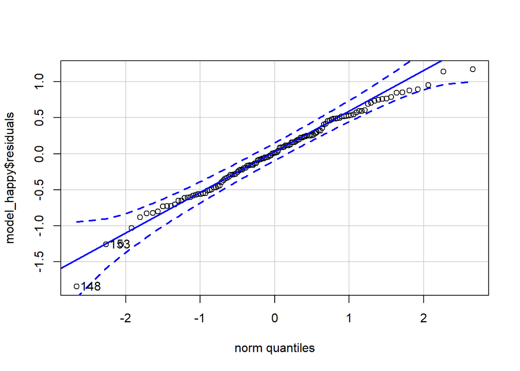

```
## 148 153
## 122 126
```

```r
qqPlot(model_happy$residuals)
```

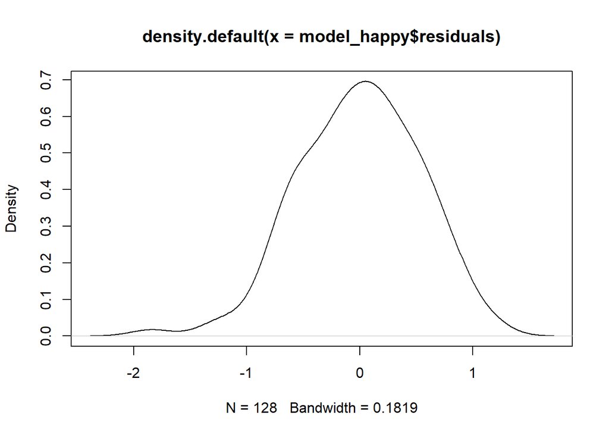

```r
plot(density(model_happy$residuals))
```

We can see that the plot above as the normality of the residual looks good .

*Heterodasticity*

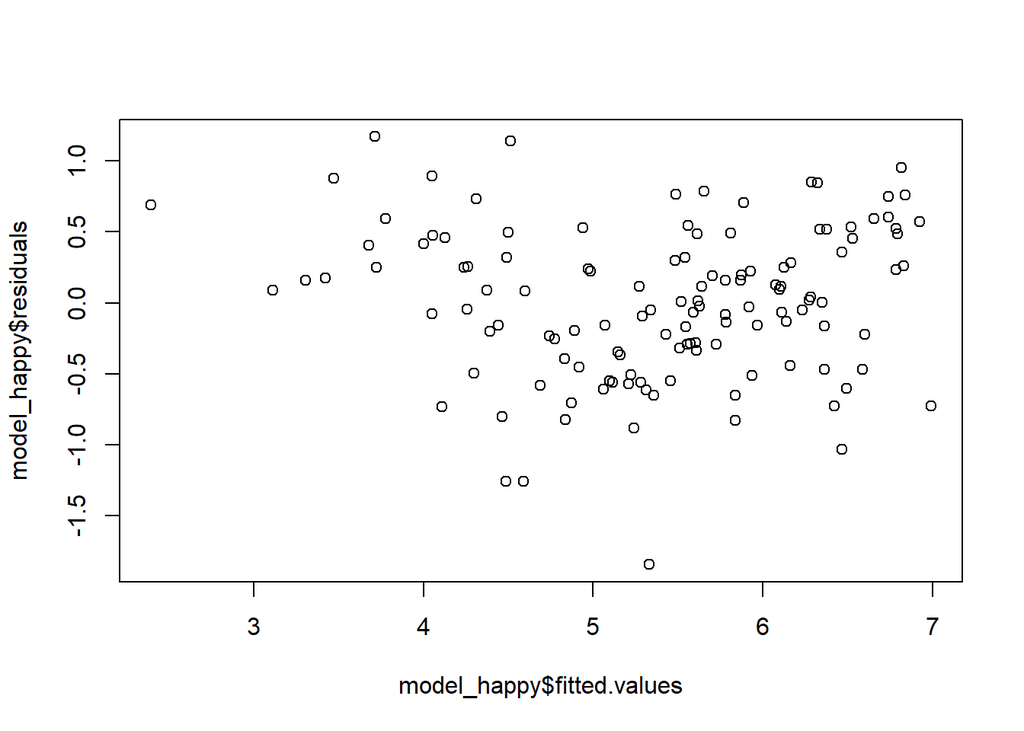

```r
plot(model_happy$fitted.values, #prediksi
     model_happy$residuals) #eror
```

If we check the plot above, we can see there is a presence of a shape. It means that heteroscedacity is present.

*Linearity*

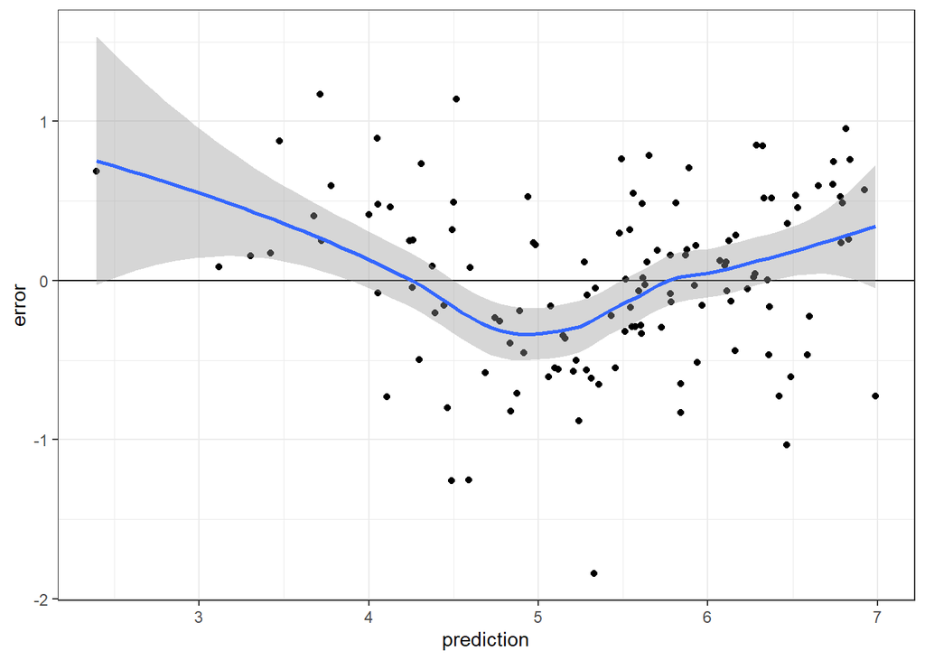

```r
data.frame(prediction=model_happy$fitted.values,
     error=model_happy$residuals) %>%
  ggplot(aes(prediction,error)) +
  geom_hline(yintercept=0) +
  geom_point() +
  geom_smooth() +
  theme_bw()
```

### Conclusion

**Based on make model for prediction (model_happy) it can be concluded:**

**1. R-Squared** **model_happy has a value of 0.753, so it means based on the R-Squared value for model_happy it can explain variation data in target variable “Score” 0.753 (75.3%)**

**2. Error** **From results of the error test using RMSE (Root Mean Squared Error) model_happy has a value of 0.5324381, so it can be said that the possibility that the model will deviate from the actual data is only 0.5324381**

**3. Assumption**

**So can be concluded that in determining happiness, an important variable can be seen from model_happy. The important variables are GDP.per.capita, Social.support, Healthy.life.expectancy, Freedom.to.make.life.choices.**